# Practical Machine Learning Course Project

Sergio Comuñas

3 de noviembre de 2016

## Background

Using devices such as Jawbone Up, Nike FuelBand, and Fitbit it is now possible to collect a large amount of data about personal activity relatively inexpensively. These type of devices are part of the quantified self movement - a group of enthusiasts who take measurements about themselves regularly to improve their health, to find patterns in their behavior, or because they are tech geeks. One thing that people regularly do is quantify how much of a particular activity they do, but they rarely quantify how well they do it. In this project, your goal will be to use data from accelerometers on the belt, forearm, arm, and dumbell of 6 participants. They were asked to perform barbell lifts correctly and incorrectly in 5 different ways. More information is available from the website here: http://groupware.les.inf.puc-rio.br/har (see the section on the Weight Lifting Exercise Dataset).

## Data

The training data for this project are available here:

https://d396qusza40orc.cloudfront.net/predmachlearn/pml-training.csv

The test data are available here:

https://d396qusza40orc.cloudfront.net/predmachlearn/pml-testing.csv

The data for this project come from this source: http://groupware.les.inf.puc-rio.br/har.

## Preliminar analysis

### Reproducibility

We will use seed 1234 and need to install several packages that are show next.

```r
## Load the necessary libraries
suppressMessages(library(caret))
suppressMessages(library(randomForest))
suppressMessages(library(rpart))

## Assure reproducibility
set.seed(1234)
```

### Load Data and analysis

First of all we will load the data in 2 packages.

```r
## Download the 2 files
url.data <- "https://d396qusza40orc.cloudfront.net/predmachlearn/pml-training.csv"
url.validate <- "https://d396qusza40orc.cloudfront.net/predmachlearn/pml-testing.csv"
download.file(url.data, "data.csv")
download.file(url.validate, "validate.csv")
```

We will do Cross-Validation partitioning the data in 30/70% for testing/training purposes. Our expected out of sample error will be measured using the accuracy for each model (OOSE = 1 - Accuracy) and we will try to minimize it.

Also will clean the data for not having NA values and extract personal data columns like User Name, etc.

```r
## Read the two files
data.in <- read.csv("data.csv", sep = ",", stringsAsFactors = FALSE,
                     na.strings=c("NA","#DIV/0!", ""))
data.in$classe <- as.factor(data.in$classe)
validate <- read.csv("validate.csv", sep = ",", stringsAsFactors = FALSE,
                 na.strings=c("NA","#DIV/0!", ""))

## Get only columns that have almost 95% correct values (not NAs) and delete
## personal data columns as: X, user_name, timestamp and windows (1:7)
data.clean <- data.in[,colSums(is.na(data.in)) <= (dim(data.in)[1] * 0.95)]
data.clean <- data.clean[, -c(1:7)]
validate <- validate[,colSums(is.na(data.in)) <= (dim(data.in)[1] * 0.95)]
validate <- validate[, -c(1:7)]

## Create training and test data
inTrain <- createDataPartition(y = data.clean$classe, p = 0.7, list = FALSE)
training <- data.clean[inTrain, ]
test <- data.clean[-inTrain, ]

## Look for Classe column to see if there are important differences
table(training$classe)
```

```
##
##    A    B    C    D    E
## 3906 2658 2396 2252 2525
```

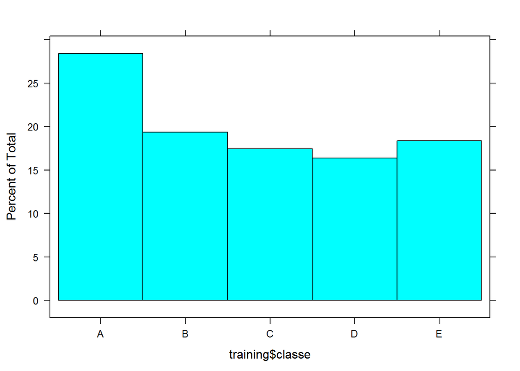

```r
histogram(training$classe)
```

You can see there is not a great diference in the amount for each class. A class is a little greater than the other ones but not so much.

## Model Creation

As we are trying to predict a factor variable and have not so much documentation about features we will try Tree models like: Decission Tree and Random Forest. With this kind of models we will not need Feature Selection phase.

Also we will use test data in order to calculate the accuracy of each model.

```r
## 1. Decission Tree
fit.dt <- rpart(classe ~ ., data = training)
result.dt <- predict(fit.dt, test, type = "class")

## 2. Random Forest
fit.rf <- randomForest(classe ~ ., data = training, method = "class")
result.rf <- predict(fit.rf, test)

## Calculate the Accuracy of each method
accuracy.dt <- confusionMatrix(result.dt, test$classe)$overall["Accuracy"]
accuracy.rf <- confusionMatrix(result.rf, test$classe)$overall["Accuracy"]
```

As you can see Random Forest have a greater accuracy (0.9969414) than Decission Tree (0.6878505). Then we will use Random Forest model in order to predict the validation data on the Submission point.

## Submission

In this point we will predict the classe value for each row on the validation dataset. We will print the most probable class.

```r
## Predict the final submission
predict(fit.rf, validate)
```

```
##  1  2  3  4  5  6  7  8  9 10 11 12 13 14 15 16 17 18 19 20
##  B  A  B  A  A  E  D  B  A  A  B  C  B  A  E  E  A  B  B  B
## Levels: A B C D E
```